# quarto-inputdbf372c497bf1efe

# 6. Análise dos gráficos de associação de variáveis

Para compreender melhor a relação entre os indicadores socioeconômicos dos municípios mineiros, foram elaborados gráficos comparando variáveis relacionadas à educação, à saúde, ao desenvolvimento humano e às finanças públicas. A partir dessas visualizações, é possível identificar tendências e padrões que ajudam a entender como esses indicadores se relacionam entre si.

Para realizar essa análise, além do recurso visual, é possível avaliar uma possível associação entre duas variáveis quantitativas (dados que expressam quantidades, medidas ou valores mensuráveis), por meio de três medidas de correlação. Em geral, essas medidas variam no intervalo de −1 a 1. Quando o valor da correlação é positivo, indica que, se uma delas aumenta, a tendência é que a outra também cresça e, da mesma forma, se uma diminui, a variável associada tende a decrescer. Por outro lado, caso essa medida seja negativa, a relação ocorre de modo que, se uma variável cresce, a outra tende a diminuir, e vice-versa.

Ademais, se o valor de uma das medidas atingir números próximos de 1 ou de −1, indica a existência de uma forte correlação entre as variáveis observadas, isto é, há um relevante grau de dependência entre elas. Caso ela seja próxima de 0, existe uma relação fraca, a qual demonstra pouca associação entre as variáveis.

Para cada tipo de medida, há uma situação a qual melhor se adequa utilizá-la. O Coeficiente de Pearson é normalmente indicado para associações lineares em que os dados não apresentam muita discrepância. Já os Coeficientes de Spearman e de Kendall são calculados a partir da ordenação dos valores em vez dos seus valores brutos, aceitando outliers.

Em relação ao banco de dados analisado, é possível enxergar algumas correlações principais e criar conclusões acerca delas a partir de seus gráficos de dispersão e dos cálculos das medidas desses coeficientes.

## 6.1 PIB per capita e escolarização

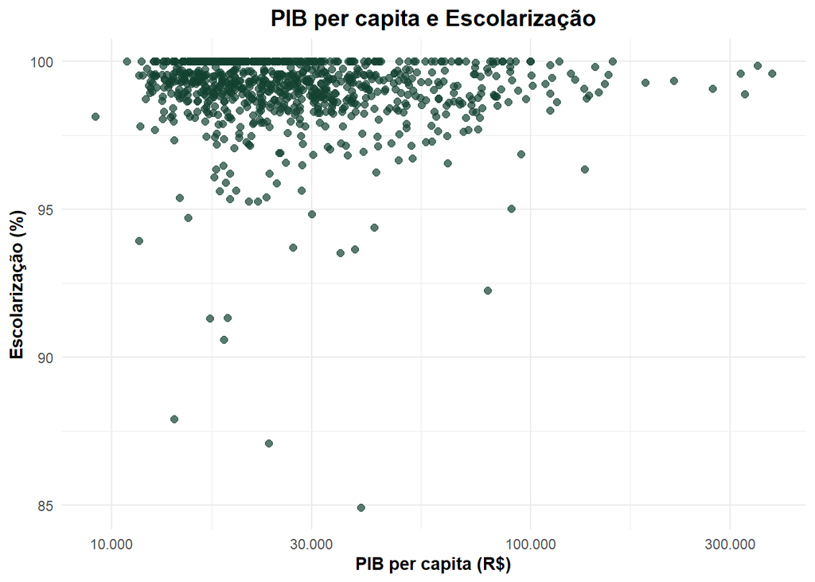

Figura 25: Gráfico de dispersão PIB per capita e escolarização

Tabela 3: PIB per capita x Escolarização

| Método | Correlação |
| --- | --- |
| Pearson | 0.000 |
| Spearman | -0.124 |
| Kendall | -0.084 |

Neste gráfico, observa-se que a escolarização permanece elevada independentemente do nível de PIB per capita do município. Tanto municípios com menor quanto com maior renda apresentam taxas de escolarização muito próximas de 100%.

Essa pouca variabilidade dos níveis de escolarização afeta relativamente os valores das medidas de correlação. Ao calcular os Coeficientes de Pearson, Spearman e Kendall, acha-se os valores -0.0002215448, -0.1242779, -0.0837641, respectivamente. O sinal poderia sugerir uma associação negativa, mas a análise visual do gráfico comprova que, na realidade, a correlação é quase nula. Tais resultados se devem, porque como quase todas as cidades possuem a mesma taxa alta, a linha do gráfico fica constante e, qualquer cidade com PIB muito fora do normal (outlier), puxa o cálculo levemente para o lado negativo.

Portanto, conclui-se que as variáveis não possuem correlação real na prática, e que outros fatores como políticas públicas educacionais e a universalização do acesso à educação básica, podem ter um papel importante nesse resultado de altos índices.

## 6.2 PIB per capita e mortalidade infantil

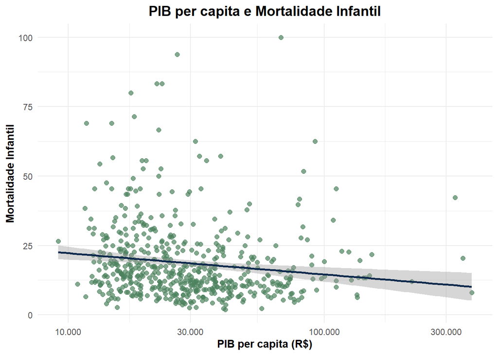

Figura 26: Gráfico de dispersão de PIB per capita e mortalidade infantil

Tabela 4: PIB per capita x Mortalidade Infantil

| Método | Correlação |
| --- | --- |
| Pearson | -0.067 |
| Spearman | -0.226 |
| Kendall | -0.150 |

Diferentemente do gráfico anterior, a relação entre PIB per capita e mortalidade infantil é mais evidente. Observa-se uma tendência de redução da mortalidade infantil conforme o PIB per capita aumenta.

Esse comportamento pode ser confirmado ao calcular os Coeficientes de Pearson, de Spearman e de Kendall, em que se acham os valores -0.06703182, -0.2258377 e -0.1495825, respectivamente. Comparando os três, nota-se que o primeiro apresenta um resultado muito menor em relação aos outros dois porque o PIB possui uma quantidade de valores que variam muito entre si (outliers). Logo, torna-se mais adequado olhar para as duas últimas medidas (-0.2258377 e -0.1495825), as quais são negativas e demonstram que, conforme uma das variáveis cresce, a outra tende a diminuir. Ademais, como esses valores variam no intervalo de 0 a 0,4, há uma correlação fraca entre elas, o que não significa que ela não exista.

Tal percepção sugere que municípios mais ricos tendem a oferecer melhores condições de saúde, infraestrutura e saneamento, fatores que contribuem diretamente para a redução dos óbitos infantis, o que reforça a importância das condições econômicas para os indicadores de saúde.

## 6.3 IDHM e escolarização

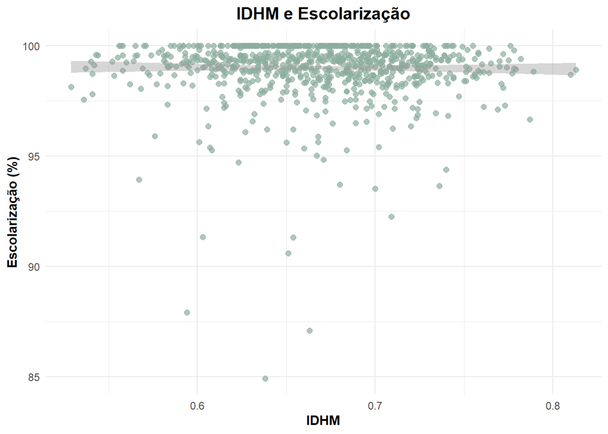

Tabela 5: IDHM x Escolarização

| Método | Correlação |
| --- | --- |
| Pearson | -0.014 |
| Spearman | -0.089 |
| Kendall | -0.060 |

Esse comportamento é muito semelhante ao observado no par anterior de PIB e escolarização. Ele afeta diretamente o valor das medidas de correlação, pois ao calcular os Coeficientes de Pearson, Spearman e Kendall, acha-se os valores -0.01375387, -0.08892231, -0.05968151, respectivamente. O valor negativo se deve, pois como a escolarização permanece muito alta e concentrada independentemente do nível de IDHM do município, há algumas flutuações que puxam o valor para baixo, embora a correlação entre elas seja quase nula. São exemplos disso, municípios com IDHM menor, mas que conseguem registrar 100% de escolarização e de cidades com IDHM mais elevado apresentam taxas ligeiramente menores.

## 6.4 Mortalidade infantil por faixa de IDHM

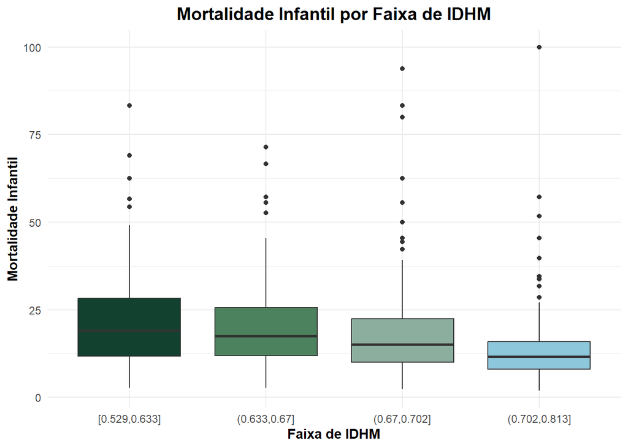

Figura 28: Gráfico boxplot de Mortalidade infantil por faixa de IDHM

Tabela 6: IDHM x Mortalidade Infantil

| Método | Correlação |
| --- | --- |
| Pearson | -0.238 |
| Spearman | -0.314 |
| Kendall | -0.211 |

O gráfico de boxplot mostra como a mortalidade infantil se comporta em diferentes faixas de IDHM. A principal tendência observada é a redução da mortalidade infantil à medida que o IDHM aumenta. Em suma, as faixas com menor desenvolvimento humano apresentam valores mais elevados de mortalidade, enquanto os municípios com IDHM mais alto concentram os menores índices.

Nesse contexto, o cálculo de correlações comprova tal comportamento ao resultar valores de Coeficientes de Pearson, Spearman e Kendall em -0.2375371, -0.3137683, -0.2105332, respectivamente. O valor negativo demonstra que enquanto uma variável cresce (IDH), há o decrescimento da outra (mortalidade). Além disso, é importante ressaltar que como esses resultados obtidos variam no intervalo de 0 a 0,4, há uma correlação fraca entre elas, o que não significa que ela não exista.

Tal percepção pode estar relacionada a fatores como melhores condições de vida, maior acesso aos serviços de saúde e melhores níveis de educação. Dessa forma, o gráfico reforça a ideia de que municípios com maior desenvolvimento humano tendem a oferecer condições mais favoráveis para a saúde da população.

## 6.5 Receitas e despesas municipais

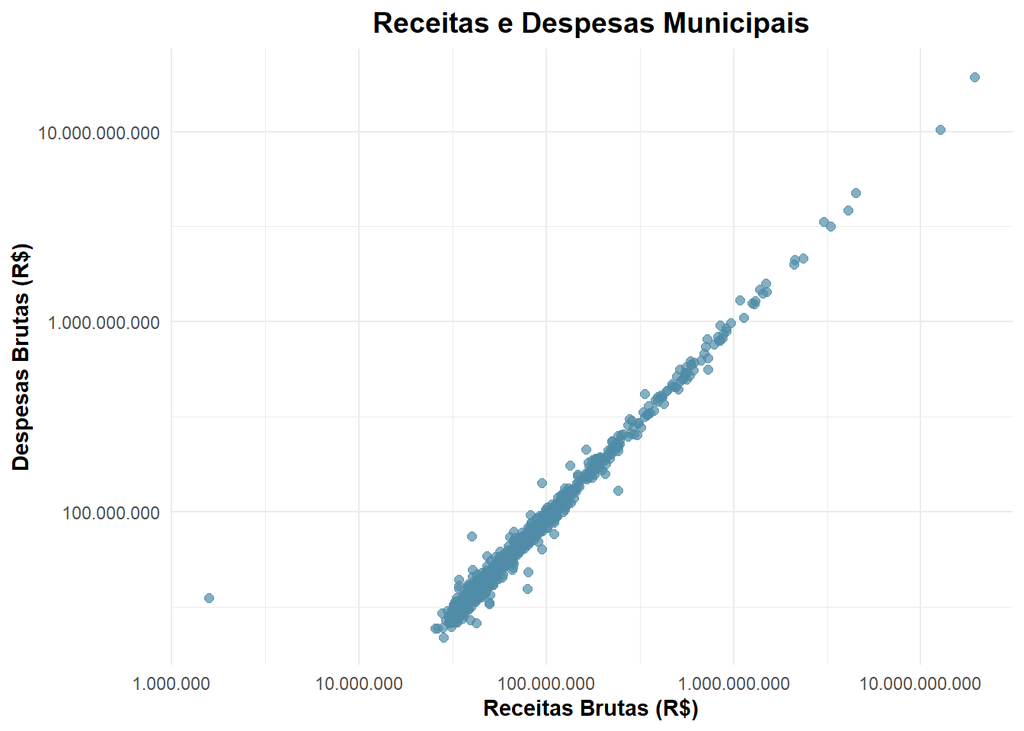

Figura 29: Gráfico de gráfico de dispersão com escala logarítmica de Receitas e despesas municipais

Tabela 7: Despesas x Receitas Brutas

| Método | Correlação |
| --- | --- |
| Pearson | 0.995 |
| Spearman | 0.982 |
| Kendall | 0.905 |

O gráfico que relaciona receitas e despesas municipais apresenta a associação mais clara entre todas as analisadas. Os pontos formam uma trajetória bastante próxima de uma linha reta linear crescente, indicando que municípios que arrecadam mais também tendem a gastar mais.

Esse destaque significativo é igualmente visto nas medidas de correlação, de modo que os Coeficientes de Pearson, de Spearman e de Kendall resultaram nos valores de 0.9952322, 0.9820892 e 0.9051228, respectivamente. Esse resultado evidencia não só o sinal positivo, o qual indica que as variáveis caminham no mesmo sentido (se uma cresce, a outra também aumenta), como também revela uma associação muito forte entre elas, já que os coeficientes estão no intervalo entre 0,7 e 1.

É importante destacar, que tal resultado era esperado, uma vez que a capacidade de investimento e de manutenção dos serviços públicos depende diretamente dos recursos disponíveis em cada município. Logo, o gráfico demonstra uma forte relação entre arrecadação e gastos públicos, refletindo a dinâmica financeira das administrações municipais.

## 6.6 PIB per capita e e IDHM

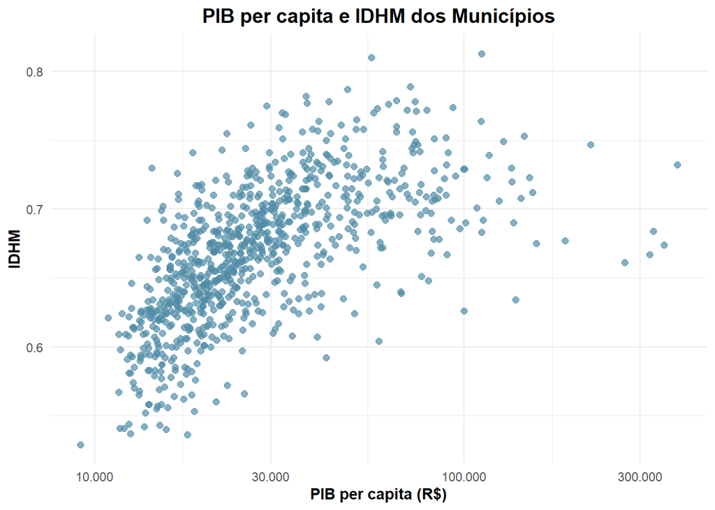

Tabela 8: PIB per capita X IDHM

| Método | Correlação |
| --- | --- |
| Pearson | 0.390 |
| Spearman | 0.702 |
| Kendall | 0.515 |

# 7. Conclusão

A partir da análise feita no desenvolver do projeto, percebe-se que Minas Gerais é um estado que apresenta uma grande quantidade de municípios, sendo que a maioria deles possui pequeno porte tanto em relação a território propriamente dito quanto em relação a aspectos financeiros. Esse fato contribui para a interpretação de que o estado possui diversas desigualdades entre as cidades, o que foi destrinchado ao longo do estudo.

É possível compreender que, por conta dessas características, a maioria das variáveis se comportam de forma extremamente heterogênea. As únicas variáveis que se apresentam de forma relativamente estável é IDHM e taxa de escolarização. Isso reflete que, apesar das desigualdades, existe um esforço relativamente bem sucedido em assegurar um estado de bem-estar social incipiente, embora haja diversas inequidades ao longo do estado de Minas Gerais, que merecem atenção.

Percebe-se, também, que algumas variáveis possuem índices de correlação muito baixos. IDHM e taxa de escolarização, por exemplo, não possuem coeficientes de correlação muito expressivos, isso pode indicar que essa parte das variáveis se comporta de forma relativamente independente. Dentre essas correlações menos intensas, chama a atenção a associação entre mortalidade infantil e IDHM, em que se compreende que, apesar de existir uma correlação fraca, ela é definitivamente maior do que as outras observadas previamente no estudo, o que dá a essa comparação um peso maior. A correlação mais forte encontrada diz respeito a receitas e despesas municipais, em que existe uma correlação linear quase perfeita, o que intuitivamente faz sentido. Além da associação entre PIB per capita e IDHM, cujo coeficiente de correlação de Spearman resultou em 0,7, indicando uma correlação positiva forte, o que mostra que municípios com mais renda tendem a serem mais desenvolvidos, ainda que o IDHM seja distribuído de forma homogênea entre os municípios de MG.

# REFERÊNCIAS

INSTITUTO BRASILEIRO DE GEOGRAFIA E ESTATÍSTICA (IBGE). Área territorial brasileira 2022. Rio de Janeiro: IBGE, 2023.

INSTITUTO BRASILEIRO DE GEOGRAFIA E ESTATÍSTICA (IBGE). Censo Demográfico 2022: população e domicílios: primeiros resultados. Rio de Janeiro: IBGE, 2023.

INSTITUTO BRASILEIRO DE GEOGRAFIA E ESTATÍSTICA (IBGE). Estimativas da população residente com data de referência em 1º de julho de 2024. Rio de Janeiro: IBGE, 2024.

INSTITUTO BRASILEIRO DE GEOGRAFIA E ESTATÍSTICA (IBGE). Censo Demográfico 2010: escolarização de 6 a 14 anos. Rio de Janeiro: IBGE, 2010.

PROGRAMA DAS NAÇÕES UNIDAS PARA O DESENVOLVIMENTO (PNUD). Atlas do Desenvolvimento Humano no Brasil. Brasília, DF: PNUD, [s.d.].

BRASIL. Ministério da Saúde. Departamento de Informática do Sistema Único de Saúde (DATASUS). Indicadores de mortalidade infantil. Brasília, DF, 2022.

BRASIL. Secretaria do Tesouro Nacional. Sistema de Informações Contábeis e Fiscais do Setor Público Brasileiro (SICONFI). Contas anuais: receitas orçamentárias realizadas (Anexo I-C) e despesas orçamentárias empenhadas (Anexo I-D), 2023. Brasília, DF, 2023. Disponível em: https://siconfi.tesouro.gov.br/siconfi/pages/public/consulta_finbra/finbra_list.jsf. Acesso em: jun. 2024.

INSTITUTO BRASILEIRO DE GEOGRAFIA E ESTATÍSTICA (IBGE). Produto Interno Bruto dos Municípios. Rio de Janeiro: IBGE, em parceria com os Órgãos Estaduais de Estatística, Secretarias Estaduais de Governo e Superintendência da Zona Franca de Manaus (SUFRAMA), [s.d.].

## APÊNDICE A – Código utilizado na análise

```r
 ##BIBLIOTECAS
library(dplyr)
library(ggplot2)
library(MetBrewer)
library(paletteer)
library(purrr)
library(readxl)
library(scales)
library(tidyr)

# Exploração inicial da base.

dim(dados)
names(dados)
str(dados)
summary(dados)

# --------------- LIVIA

# Renomeação das variáveis.
dados <- dados %>%
  rename(
    municipio = `Município [-]`,
    area_territorial = `Área Territorial - km² [2025]`,
    populacao = `População no último censo - pessoas [2022]`,
    densidade_demografica = `Densidade demográfica - hab/km² [2022]`,
    populacao_estimada = `População estimada - pessoas [2025]`,
    escolarizacao = `Escolarização <span>6 a 14 anos</span> - % [2022]`,
    idhm = `IDHM <span>Índice de desenvolvimento humano municipal</span> [2010]`,
    mortalidade_infantil = `Mortalidade infantil - óbitos por mil nascidos vivos [2023]`,
    receitas_brutas = `Total de receitas brutas realizadas - R$ [2024]`,
    despesas_brutas = `Total de despesas brutas empenhadas - R$ [2024]`,
    pib_per_capita = `PIB per capita - R$ [2023]`
  )

names(dados)

# Verificação de valores ausentes.

colSums(is.na(dados))

# Resumo dos valores ausentes.

faltantes <- data.frame(
  variavel = names(dados),
  n_na = colSums(is.na(dados)),
  perc_na = round(
    colSums(is.na(dados)) / nrow(dados) * 100,
    2
  )
)

faltantes


# Identificação de registros inválidos.

sum(dados$mortalidade_infantil == "-")

# Tratamento de valores ausentes.

dados <- dados %>%
  mutate(
    mortalidade_infantil = na_if(
      mortalidade_infantil,
      "-"
    )
  )
# Conversão para formato numérico.
dados <- dados %>%
  mutate(
    mortalidade_infantil =
      as.numeric(mortalidade_infantil))

str(dados)



colSums(is.na(dados))

faltantes_finais <- data.frame(
  variavel = names(dados),
  n_na = colSums(is.na(dados)),
  perc_na = round(
    colSums(is.na(dados)) / nrow(dados) * 100,
    2))

faltantes_finais


# Verificação de duplicidades.
sum(duplicated(dados$municipio))


# Verificação de valores extremos.

range(dados$idhm, na.rm = TRUE)

range(dados$escolarizacao, na.rm = TRUE)

min(dados$mortalidade_infantil, na.rm = TRUE)

min(dados$area_territorial)

min(dados$populacao)

min(dados$populacao_estimada)

min(dados$pib_per_capita)

min(dados$receitas_brutas)

min(dados$despesas_brutas)


# Resumo da base tratada.
str(dados)
summary(dados)

# Definição de cores e tema gráfico.

cores <- paletteer::paletteer_d("MetBrewer::Pissaro")

tema_trabalho <- theme_minimal() +
  theme(
    plot.title = element_text(
      face = "bold",
      hjust = 0.5,
      size = 14
    ),
    axis.title = element_text(face = "bold")
  )

# Relação entre PIB e escolarização.

ggplot(
  dados,
  aes(
    x = pib_per_capita,
    y = escolarizacao
  )
) +
  geom_point(
    color = cores[1],
    alpha = 0.7,
    size = 2
  ) +
  scale_x_log10(
    labels = label_number(big.mark = ".")
  ) +
  labs(
    title = "PIB per capita e Escolarização",
    x = "PIB per capita (R$)",
    y = "Escolarização (%)"
  ) +
  tema_trabalho

# Relação entre PIB e mortalidade infantil.

ggplot(
  dados,
  aes(
    x = pib_per_capita,
    y = mortalidade_infantil
  )
) +
  geom_point(
    color = cores[2],
    alpha = 0.7,
    size = 2
  ) +
  geom_smooth(
    method = "lm",
    se = TRUE,
    color = cores[7]
  ) +
  scale_x_log10(
    labels = label_number(big.mark = ".")
  ) +
  labs(
    title = "PIB per capita e Mortalidade Infantil",
    x = "PIB per capita (R$)",
    y = "Mortalidade Infantil"
  ) +
  tema_trabalho
# Relação entre IDHM e escolarização.

ggplot(
  dados,
  aes(
    x = idhm,
    y = escolarizacao
  )
) +
  geom_point(
    color = cores[3],
    alpha = 0.7,
    size = 2
  ) +
  geom_smooth(
    method = "lm",
    se = TRUE,
    color = cores[8]
  ) +
  labs(
    title = "IDHM e Escolarização",
    x = "IDHM",
    y = "Escolarização (%)"
  ) +
  tema_trabalho

# Criação das faixas de IDHM.

dados$faixa_idhm <- cut(
  dados$idhm,
  breaks = quantile(
    dados$idhm,
    probs = seq(0, 1, 0.25),
    na.rm = TRUE
  ),
  include.lowest = TRUE
)

# Mortalidade por faixa de IDHM.
ggplot(
  dados,
  aes(
    x = faixa_idhm,
    y = mortalidade_infantil,
    fill = faixa_idhm
  )
) +
  geom_boxplot() +
  scale_fill_paletteer_d("MetBrewer::Pissaro") +
  labs(
    title = "Mortalidade Infantil por Faixa de IDHM",
    x = "Faixa de IDHM",
    y = "Mortalidade Infantil"
  ) +
  tema_trabalho +
  theme(
    legend.position = "none"
  )

# Relação entre receitas e despesas.

ggplot(
  dados,
  aes(
    x = receitas_brutas,
    y = despesas_brutas
  )
) +
  geom_point(
    color = cores[5],
    alpha = 0.7,
    size = 2
  ) +
  scale_x_log10(
    labels = label_number(big.mark = ".")
  ) +
  scale_y_log10(
    labels = label_number(big.mark = ".")
  ) +
  labs(
    title = "Receitas e Despesas Municipais",
    x = "Receitas Brutas (R$)",
    y = "Despesas Brutas (R$)"
  ) +
  tema_trabalho

# Padronização das variáveis.

dados <- dados %>%
  mutate(
    z_pib = as.numeric(scale(pib_per_capita)),
    z_idhm = as.numeric(scale(idhm)),
    z_escolarizacao = as.numeric(scale(escolarizacao)),
    z_mortalidade = -as.numeric(scale(mortalidade_infantil))
  )

# Construção do índice de desenvolvimento.
dados <- dados %>%
  mutate(
    indice_desenvolvimento =
      (z_pib +
         z_idhm +
         z_escolarizacao +
         z_mortalidade) / 4
  )

# Remoção de valores ausentes.
dados_rank <- dados %>%
  filter(!is.na(indice_desenvolvimento))

# Criação do ranking.
ranking <- dados_rank %>%
  arrange(desc(indice_desenvolvimento))

top10 <- ranking %>%
  select(municipio, indice_desenvolvimento) %>%
  slice(1:10)

dados_rank <- dados_rank %>%
  mutate(
    quartil_desenvolvimento =
      ntile(indice_desenvolvimento, 4)
  )
# Classificação dos níveis de desenvolvimento.

dados_rank <- dados_rank %>%
  mutate(
    categoria_desenvolvimento =
      case_when(
        quartil_desenvolvimento == 1 ~ "Baixo",
        quartil_desenvolvimento == 2 ~ "Médio-Baixo",
        quartil_desenvolvimento == 3 ~ "Médio-Alto",
        quartil_desenvolvimento == 4 ~ "Alto"
      )
  )
```

```r
# Ranking dos municípios mais desenvolvidos.
ggplot(top10,
       aes(x = reorder(municipio,
                       indice_desenvolvimento),
           y = indice_desenvolvimento,
           fill = indice_desenvolvimento)) +
  geom_col() +
  coord_flip() +
  scale_fill_gradientn(colors = cores) +
  labs(
    title = "Top 10 Municípios Mais Desenvolvidos de Minas Gerais",
    x = "Município",
    y = "Índice de Desenvolvimento"
  ) +
  theme_minimal() +
  theme(
    legend.position = "none"
  )

# --------------- HÁGATA - medidas de resumo para variáveis numéricas
numericas <- dados %>% select(where(is.numeric))
# selecionando numéricas

estatisticas <- data.frame(
  Variavel = names(numericas),
  Media = round(sapply(numericas, mean, na.rm = TRUE), 2),
  Mediana = round(sapply(numericas, median, na.rm = TRUE), 2),
  Minimo = round(sapply(numericas, min, na.rm = TRUE), 2),
  Maximo = round(sapply(numericas, max, na.rm = TRUE), 2),
  DP = round(sapply(numericas, sd, na.rm = TRUE), 2),
  CV = round(sapply(numericas, function(x) (sd(x, na.rm = TRUE) / mean(x, na.rm = TRUE)) * 100), 2)
)
# calculando estatísticas
print(estatisticas)
write.csv(estatisticas, "estatisticas_descritivas.csv", row.names = FALSE)

# CORREÇÃO AQUI: Filtrar apenas as 10 variáveis principais antes de calcular as médias
colunas_principais <- c(
  "area_territorial", "populacao", "densidade_demografica",
  "populacao_estimada", "escolarizacao", "idhm",
  "mortalidade_infantil", "receitas_brutas", "despesas_brutas", "pib_per_capita"
)
dados_principais <- numericas %>% select(all_of(colunas_principais))

tabela_resumida <- data.frame(
  Variável = c(
    "Área Territorial (km²)",
    "População (Censo 2022)",
    "Densidade Demográfica (hab/km²)",
    "População Estimada (2025)",
    "Escolarização 6-14 anos (%)",
    "IDHM",
    "Mortalidade Infantil (óbitos/1000)",
    "Receitas Brutas (R$)",
    "Despesas Brutas (R$)",
    "PIB per Capita (R$)"
  ),

  Média = round(sapply(dados_principais, mean, na.rm = TRUE), 2),
  Mediana = round(sapply(dados_principais, median, na.rm = TRUE), 2),
  Mínimo = round(sapply(dados_principais, min, na.rm = TRUE), 2),
  Máximo = round(sapply(dados_principais, max, na.rm = TRUE), 2),
  CV = round(sapply(dados_principais, function(x) (sd(x, na.rm = TRUE) / mean(x, na.rm = TRUE)) * 100), 2)
)

tabela_resumida$Média <- format(tabela_resumida$Média, big.mark = ".", decimal.mark = ",")
tabela_resumida$Mediana <- format(tabela_resumida$Mediana, big.mark = ".", decimal.mark = ",")
tabela_resumida$Mínimo <- format(tabela_resumida$Mínimo, big.mark = ".", decimal.mark = ",")
tabela_resumida$Máximo <- format(tabela_resumida$Máximo, big.mark = ".", decimal.mark = ",")

print(tabela_resumida)
# criando tabela resumida

encontrar_municipio <- function(df, var, tipo = "max") {
  df_clean <- df[!is.na(df[[var]]), ]

  if (nrow(df_clean) == 0) {
    return(NA)
  }

  if (tipo == "max") {
    valor <- max(df_clean[[var]], na.rm = TRUE)
  } else {
    valor <- min(df_clean[[var]], na.rm = TRUE)
  }

  municipios <- df_clean$municipio[df_clean[[var]] == valor]

  return(municipios[1])
}

tabela_extremos <- data.frame(
     Variável = c(
           "Área Territorial (km²)",
           "População (Censo 2022)",
           "Densidade Demográfica (hab/km²)",
           "População Estimada (2025)",
           "Escolarização 6-14 anos (%)",
           "IDHM",
           "Mortalidade Infantil (óbitos/1000)",
           "Receitas Brutas (R$)",
           "Despesas Brutas (R$)",
           "PIB per Capita (R$)"
        ),

        `Mínimo` = c(
             min(dados$area_territorial, na.rm = TRUE),
             min(dados$populacao, na.rm = TRUE),
             min(dados$densidade_demografica, na.rm = TRUE),
             min(dados$populacao_estimada, na.rm = TRUE),
              min(dados$escolarizacao, na.rm = TRUE),
              min(dados$idhm, na.rm = TRUE),
              min(dados$mortalidade_infantil, na.rm = TRUE),
             min(dados$receitas_brutas, na.rm = TRUE),
             min(dados$despesas_brutas, na.rm = TRUE),
              min(dados$pib_per_capita, na.rm = TRUE)
         ),

       `Município (Mín)` = c(
             encontrar_municipio(dados, "area_territorial", "min"),
             encontrar_municipio(dados, "populacao", "min"),
             encontrar_municipio(dados, "densidade_demografica", "min"),
             encontrar_municipio(dados, "populacao_estimada", "min"),
             encontrar_municipio(dados, "escolarizacao", "min"),
            encontrar_municipio(dados, "idhm", "min"),
             encontrar_municipio(dados, "mortalidade_infantil", "min"),
             encontrar_municipio(dados, "receitas_brutas", "min"),
             encontrar_municipio(dados, "despesas_brutas", "min"),
              encontrar_municipio(dados, "pib_per_capita", "min")
          ),

        `Máximo` = c(
             max(dados$area_territorial, na.rm = TRUE),
               max(dados$populacao, na.rm = TRUE),
           max(dados$densidade_demografica, na.rm = TRUE),
             max(dados$populacao_estimada, na.rm = TRUE),
               max(dados$escolarizacao, na.rm = TRUE),
               max(dados$idhm, na.rm = TRUE),
               max(dados$mortalidade_infantil, na.rm = TRUE),
               max(dados$receitas_brutas, na.rm = TRUE),
               max(dados$despesas_brutas, na.rm = TRUE),
               max(dados$pib_per_capita, na.rm = TRUE)
           ),

         `Município (Máx)` = c(
               encontrar_municipio(dados, "area_territorial", "max"),
               encontrar_municipio(dados, "populacao", "max"),
               encontrar_municipio(dados, "densidade_demografica", "max"),
               encontrar_municipio(dados, "populacao_estimada", "max"),
               encontrar_municipio(dados, "escolarizacao", "max"),
               encontrar_municipio(dados, "idhm", "max"),
               encontrar_municipio(dados, "mortalidade_infantil", "max"),
               encontrar_municipio(dados, "receitas_brutas", "max"),
               encontrar_municipio(dados, "despesas_brutas", "max"),
               encontrar_municipio(dados, "pib_per_capita", "max")
           )
   )
```

```r
   tabela_extremos$Mínimo <- format(round(tabela_extremos$Mínimo, 2),
    big.mark = ".", decimal.mark = ",")
 tabela_extremos$Máximo <- format(round(tabela_extremos$Máximo, 2),
     big.mark = ".", decimal.mark = ",")

   #exibir
   print(tabela_extremos)

# --------------- Geovanna  --------------- <3


dadosnum <- names(dados)[sapply(dados, is.numeric)]
 numlg <- dados %>%
     select(all_of(dadosnum)) %>%
     pivot_longer(cols = everything(), names_to = "Variavel", values_to = "Valor")

#Gráficos de todas variáveis
#HISTOGRAMA
  ggplot(numlg, aes(x = Valor)) +
    geom_histogram(fill = cores[1], color = "black", bins = 30, na.rm = TRUE) +
    facet_wrap(~Variavel, scales = "free") +
    labs( title = "Histogramas das Variáveis",
       x = "Valores",
       y = "Frequência") + tema_trabalho

#BOXPLOT
  ggplot(numlg, aes(y = Valor)) +
    geom_boxplot(fill = cores[4], color = "black", na.rm = TRUE) +
    facet_wrap(~Variavel, scales = "free") +
    labs(title = "Boxplots das Variáveis",
      y = "Valores",
      x = "") +
    tema_trabalho +
    theme(
      axis.text.x = element_blank(),
      axis.ticks.x = element_blank())
#10 municipios
#FILTRAR
  maiores_areas <- dados %>%
    arrange(desc(area_territorial)) %>%
    slice_head(n = 10)

#GRÁFICO PIB PER CAPITA
  ggplot(maiores_areas, aes(x = reorder(municipio, -pib_per_capita), y = pib_per_capita)) +
    geom_col(fill = cores[2], color = "black", alpha = 0.8) +
    scale_y_continuous(labels = scales::label_number(big.mark = ".", decimal.mark = ",")) +
    labs( title = "PIB per Capita dos 10 Maiores Municípios em Área de MG",
      x = "Município",
      y = "PIB per Capita (R$)") + tema_trabalho +
    theme(axis.text.x = element_text(angle = 45, hjust = 1))

##graficos isolados (boxplot)
#ÁREA TERRITORIAL
  ggplot(dados, aes(y = area_territorial)) +
    geom_boxplot(fill = cores[4], color = "black", na.rm = TRUE) +
    scale_y_continuous(labels = scales::label_number(big.mark = ".", decimal.mark = ",")) +
    labs(title = "Boxplot área Territorial (km²)", y = "Área Territorial", x = "") +
    tema_trabalho + theme(axis.text.x = element_blank(), axis.ticks.x = element_blank())

#POPULAÇÃO
  ggplot(dados, aes(y = populacao)) +
    geom_boxplot(fill = cores[4], color = "black", na.rm = TRUE) +
    scale_y_continuous(labels = scales::label_number(big.mark = ".", decimal.mark = ",")) +
    labs(title = "População", y = "População (pessoas)", x = "") +
    tema_trabalho + theme(axis.text.x = element_blank(), axis.ticks.x = element_blank())

#DENSIDADE DEMOGRÁFICA
  ggplot(dados, aes(y = densidade_demografica)) +
    geom_boxplot(fill = cores[4], color = "black", na.rm = TRUE) +
    scale_y_continuous(labels = scales::label_number(big.mark = ".", decimal.mark = ",")) +
    labs(title = "Boxplot Densidade Demográfica (hab/km²)", y = "Densidade Demográfica", x = "") +
    tema_trabalho + theme(axis.text.x = element_blank(), axis.ticks.x = element_blank())

#POPULAÇÃO ESTIMADA
  ggplot(dados, aes(y = populacao_estimada)) +
    geom_boxplot(fill = cores[4], color = "black", na.rm = TRUE) +
    scale_y_continuous(labels = scales::label_number(big.mark = ".", decimal.mark = ",")) +
    labs(title = "Boxplot População estimada", y = "População Estimada (Pessoas)", x = "") +
    tema_trabalho + theme(axis.text.x = element_blank(), axis.ticks.x = element_blank())

#ESCOLARIZAÇÃO
  ggplot(dados, aes(y = escolarizacao)) +
    geom_boxplot(fill = cores[4], color = "black", na.rm = TRUE) +
    scale_y_continuous(labels = scales::label_number(big.mark = ".", decimal.mark = ",")) +
    labs(title = "boxplot Taxa de Escolarização (6 a 14 anos)", y = "Escolarização (%)", x = "") +
    tema_trabalho + theme(axis.text.x = element_blank(), axis.ticks.x = element_blank())

#IDHM
  ggplot(dados, aes(y = idhm)) +
    geom_boxplot(fill = cores[4], color = "black", na.rm = TRUE) +
    scale_y_continuous(labels = scales::label_number(big.mark = ".", decimal.mark = ",")) +
    labs(title = "Boxplot IDHM", y = "Índice de Desenvolvimento Humano Municipal", x = "") +
    tema_trabalho + theme(axis.text.x = element_blank(), axis.ticks.x = element_blank())

#MORTALIDADE INFANTIL
  ggplot(dados, aes(y = mortalidade_infantil)) +
    geom_boxplot(fill = cores[4], color = "black", na.rm = TRUE) +
    scale_y_continuous(labels = scales::label_number(big.mark = ".", decimal.mark = ",")) +
    labs(title = "Boxplot mortalidade infantil", y = "Óbitos por mil nascidos vivos", x = "") +
    tema_trabalho + theme(axis.text.x = element_blank(), axis.ticks.x = element_blank())

#RECEITAS BRUTAS
  ggplot(dados, aes(y = receitas_brutas)) +
    geom_boxplot(fill = cores[4], color = "black", na.rm = TRUE) +
    scale_y_continuous(labels = scales::label_number(big.mark = ".", decimal.mark = ",")) +
    labs(title = "Boxplo Receitas Brutas", y = "Receitas (R$)", x = "") +
    tema_trabalho + theme(axis.text.x = element_blank(), axis.ticks.x = element_blank())

#DESPESAS BRUTAS
  ggplot(dados, aes(y = despesas_brutas)) +
    geom_boxplot(fill = cores[4], color = "black", na.rm = TRUE) +
    scale_y_continuous(labels = scales::label_number(big.mark = ".", decimal.mark = ",")) +
    labs(title = "Boxplot Despesas Brutas", y = "Despesas (R$)", x = "") +
    tema_trabalho + theme(axis.text.x = element_blank(), axis.ticks.x = element_blank())

#PIB PER CAPITA
  ggplot(dados, aes(y = pib_per_capita)) +
    geom_boxplot(fill = cores[4], color = "black", na.rm = TRUE) +
    scale_y_continuous(labels = scales::label_number(big.mark = ".", decimal.mark = ",")) +
    labs(title = "Boxplot PIB per Capita", y = "PIB per Capita (R$)", x = "") +
    tema_trabalho + theme(axis.text.x = element_blank(), axis.ticks.x = element_blank())

##graficos isolados (boxplot)
#ÁREA TERRITORIAL
  ggplot(dados, aes(x = area_territorial)) +
    geom_histogram(fill = cores[1], color = "black", bins = 30, na.rm = TRUE) +
    scale_x_continuous(labels = scales::label_number(big.mark = ".", decimal.mark = ",")) +
    labs(title = "Histograma Área Territorial (km²)", x = "Área Territorial", y = "Frequência") +
    tema_trabalho
```

```r
#POPULAÇÃO
  ggplot(dados, aes(x = populacao)) +
    geom_histogram(fill = cores[1], color = "black", bins = 30, na.rm = TRUE) +
    scale_x_continuous(labels = scales::label_number(big.mark = ".", decimal.mark = ",")) +
    labs(title = "Histograma População", x = "População (Pessoas)", y = "Frequência") +
    tema_trabalho

#DENSIDADE DEMOGRÁFICA
  ggplot(dados, aes(x = densidade_demografica)) +
    geom_histogram(fill = cores[1], color = "black", bins = 30, na.rm = TRUE) +
    scale_x_continuous(labels = scales::label_number(big.mark = ".", decimal.mark = ",")) +
    labs(title = "Histograma Densidade Demográfica (hab/km²)", x = "Densidade Demográfica", y = "Frequência") +
    tema_trabalho

#POPULAÇAO ESTIMADA
  ggplot(dados, aes(x = populacao_estimada)) +
    geom_histogram(fill = cores[1], color = "black", bins = 30, na.rm = TRUE) +
    scale_x_continuous(labels = scales::label_number(big.mark = ".", decimal.mark = ",")) +
    labs(title = "Histograma População Extimada", x = "População Estimada (Pessoas)", y = "Frequência") +
    tema_trabalho

#ESCOLARIZAÇÃO
  ggplot(dados, aes(x = escolarizacao)) +
    geom_histogram(fill = cores[1], color = "black", bins = 30, na.rm = TRUE) +
    scale_x_continuous(labels = scales::label_number(big.mark = ".", decimal.mark = ",")) +
    labs(title = "Histograma Taxa de Escolarização (6 a 14 anos)", x = "Escolarização (%)", y = "Frequência") +
    tema_trabalho

#IDHM
  ggplot(dados, aes(x = idhm)) +
    geom_histogram(fill = cores[1], color = "black", bins = 30, na.rm = TRUE) +
    scale_x_continuous(labels = scales::label_number(big.mark = ".", decimal.mark = ",")) +
    labs(title = "Histograma IDHM", x = "Índice de Desenvolvimento Humano Municipal", y = "Frequência") +
    tema_trabalho

#MORTALIDADE INFANTIL
  ggplot(dados, aes(x = mortalidade_infantil)) +
    geom_histogram(fill = cores[1], color = "black", bins = 30, na.rm = TRUE) +
    scale_x_continuous(labels = scales::label_number(big.mark = ".", decimal.mark = ",")) +
    labs(title = "Histograma Mortalidade Infantil", x = "Óbitos por mil nascidos vivos", y = "Frequência") +
    tema_trabalho

#RECEITA
  ggplot(dados, aes(x = receitas_brutas)) +
    geom_histogram(fill = cores[1], color = "black", bins = 30, na.rm = TRUE) +
    scale_x_continuous(labels = scales::label_number(big.mark = ".", decimal.mark = ",")) +
    labs(title = "Histograma Receitas Brutas", x = "Receitas (R$)", y = "Frequência") +
    tema_trabalho

#DESPESAS BRUTAS
  ggplot(dados, aes(x = despesas_brutas)) +
    geom_histogram(fill = cores[1], color = "black", bins = 30, na.rm = TRUE) +
    scale_x_continuous(labels = scales::label_number(big.mark = ".", decimal.mark = ",")) +
    labs(title = "Histograma Despesas Brutas ", x = "Despesas (R$)", y = "Frequência") +
    tema_trabalho

#PIB PR CAPITA
  ggplot(dados, aes(x = pib_per_capita)) +
    geom_histogram(fill = cores[1], color = "black", bins = 30, na.rm = TRUE) +
    scale_x_continuous(labels = scales::label_number(big.mark = ".", decimal.mark = ",")) +
    labs(title = "Histograma PIB per Capita", x = "PIB per Capita (R$)", y = "Frequência") +
    tema_trabalho


  # ALICE
  # Cálculo das correlações

  library(tidyverse)
  library(vcd)


  # PIB x Escolarização
  pib_escol_pearson  <- cor(dados$pib_per_capita, dados$escolarizacao, method = "pearson")
  pib_escol_spearman <- cor(dados$pib_per_capita, dados$escolarizacao, method = "spearman")
  pib_escol_kendall  <- cor(dados$pib_per_capita, dados$escolarizacao, method = "kendall")

  # PIB x Mortalidade
  pib_mort_pearson  <- cor(dados$pib_per_capita, dados$mortalidade_infantil, method = "pearson", use = "complete.obs")
  pib_mort_spearman <- cor(dados$pib_per_capita, dados$mortalidade_infantil, method = "spearman", use = "complete.obs")
  pib_mort_kendall  <- cor(dados$pib_per_capita, dados$mortalidade_infantil, method = "kendall", use = "complete.obs")

  # IDH x Escolarização
  idh_escol_pearson  <- cor(dados$idhm, dados$escolarizacao, method = "pearson", use = "complete.obs")
  idh_escol_spearman <- cor(dados$idhm, dados$escolarizacao, method = "spearman", use = "complete.obs")
  idh_escol_kendall  <- cor(dados$idhm, dados$escolarizacao, method = "kendall", use = "complete.obs")

  # Mortalidade infantil x IDH
  idh_mort_pearson  <- cor(dados$idhm, dados$mortalidade_infantil, method = "pearson", use = "complete.obs")
  idh_mort_spearman <- cor(dados$idhm, dados$mortalidade_infantil, method = "spearman", use = "complete.obs")
  idh_mort_kendall  <- cor(dados$idhm, dados$mortalidade_infantil, method = "kendall", use = "complete.obs")

  # Receitas x Despesas Municipais
  desp_rec_pearson  <- cor(dados$despesas_brutas, dados$receitas_brutas, method = "pearson", use = "complete.obs")
  desp_rec_spearman <- cor(dados$despesas_brutas, dados$receitas_brutas, method = "spearman", use = "complete.obs")
  desp_rec_kendall  <- cor(dados$despesas_brutas, dados$receitas_brutas, method = "kendall", use = "complete.obs")


  # PIB per capita x IDHM

  pib_idhm_pearson  <- cor(dados$pib_per_capita, dados$idhm, method = "pearson")
  pib_idhm_spearman <- cor(dados$pib_per_capita, dados$idhm, method = "spearman")
  pib_idhm_kendall  <- cor(dados$pib_per_capita, dados$idhm, method = "kendall")

  # ---- Tabelas separadas ----

  tabela_pib_escol <- tibble(
    Método = c("Pearson", "Spearman", "Kendall"),
    Correlação = round(c(pib_escol_pearson, pib_escol_spearman, pib_escol_kendall), 3)
  )

  tabela_pib_mort <- tibble(
    Método = c("Pearson", "Spearman", "Kendall"),
    Correlação = round(c(pib_mort_pearson, pib_mort_spearman, pib_mort_kendall), 3)
  )

  tabela_idh_escol <- tibble(
    Método = c("Pearson", "Spearman", "Kendall"),
    Correlação = round(c(idh_escol_pearson, idh_escol_spearman, idh_escol_kendall), 3)
  )

  tabela_idh_mort <- tibble(
    Método = c("Pearson", "Spearman", "Kendall"),
    Correlação = round(c(idh_mort_pearson, idh_mort_spearman, idh_mort_kendall), 3)
  )

  tabela_desp_rec <- tibble(
    Método = c("Pearson", "Spearman", "Kendall"),
    Correlação = round(c(desp_rec_pearson, desp_rec_spearman, desp_rec_kendall), 3)
  )
```

```r
  tabela_idh_pib <- tibble(
    Método = c("Pearson", "Spearman", "Kendall"),
    Correlação = round(c( pib_idhm_pearson,pib_idhm_spearman ,pib_idhm_kendall ), 3)
  )




  # 10 maiores municípios em IDHM
  top10_idhm <- dados %>%
    top_n(10, wt = idhm) %>%
    arrange(desc(idhm))

  # Gráfico de barras
  ggplot(top10_idhm, aes(x = reorder(municipio, -idhm), y = idhm)) +
    geom_bar(stat = "identity", fill = "#2E5A44", color = "black") +
    labs(
      title = "Os 10 Maiores Municípios em IDHM de MG",
      x = "Município",
      y = "Índice de Desenvolvimento Humano Municipal (IDHM)"
    ) +
    theme_minimal() +
    theme(
      plot.title = element_text(face = "bold", h_index = 0.5, size = 14),
      axis.text.x = element_text(angle = 45, hjust = 1, size = 10),
      panel.grid.major.x = element_blank()
    )
```